# PA_template.Rmd

Dennis Beardsley

May 15, 2016

# Reproducible Research Assignment # 1

##### In this assignment we will use activity data to answer some questions and use a single R markdown document to display in HTML.

## Loading and preprocessing the data

##### Load any libraries that will be needed to answer all questions and read in and preprocess the data as necessary

```r
#load library
library("ggplot2")
# read in the data
AD <- read.csv("C:/Users/Dennis/Documents/R/Data/RepData/activity.csv")

# We can ignore the missing data for calculating the mean and median
cleanAD <- complete.cases(AD)
```

## What is mean total number of steps taken per day?

##### For this question we can ignore missing values in the dataset. We will calculate (and show) the steps taken per day, create a histogram that shows steps taken per day and report the mean and median steps taken per day

```r
# Calculate the total steps taken each day
aggStepsDay <- aggregate(steps ~ date, data = AD[cleanAD, ], sum)
print(aggStepsDay)
```

```
##          date steps
## 1  10/10/2012  9900
## 2  10/11/2012 10304
## 3  10/12/2012 17382
## 4  10/13/2012 12426
## 5  10/14/2012 15098
## 6  10/15/2012 10139
## 7  10/16/2012 15084
## 8  10/17/2012 13452
## 9  10/18/2012 10056
## 10 10/19/2012 11829
## 11  10/2/2012   126
## 12 10/20/2012 10395
## 13 10/21/2012  8821
## 14 10/22/2012 13460
```

[output cut: 39 more lines]

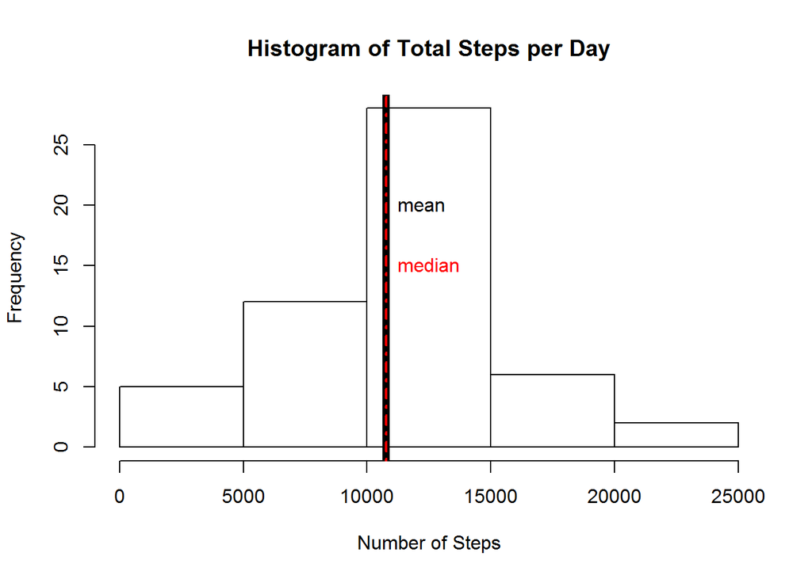

```r
# plot histogram of steps taken each day and add median and mean vertical
# line to the plot as well
meanSteps <- mean(aggStepsDay$steps)
medianSteps <- median(aggStepsDay$steps)

hist(aggStepsDay$steps, main = "Histogram of Total Steps per Day", xlab = "Number of Steps")
abline(v=meanSteps, lty=1, lwd=6, col="black")
text(meanSteps, 20, pos=4, labels="mean", col="black")
abline(v=medianSteps, lty=4, lwd=2, col="red")
text(medianSteps, 15, pos=4, labels = "median", col="red")
```

```r
# let's show the mean and median values too
sprintf("mean = %.1f", meanSteps)
```

```
## [1] "mean = 10766.2"
```

```r
sprintf("median = %.1f", medianSteps)
```

```
## [1] "median = 10765.0"
```

#### *The mean total number of steps taken per day is 10,766 and the median is 10,765*

## What is the average daily activity pattern?

##### Show a time series plot of the 5-minute interval averaged across all days and show which interval contains the maximum number of steps

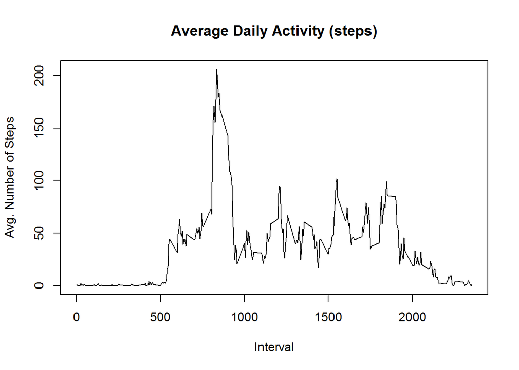

```r
aggStepsInterval <- aggregate(steps ~ interval, data = AD[cleanAD, ], mean)

plot(aggStepsInterval$interval, aggStepsInterval$steps, type = "l", main = "Average Daily Activity (steps)", xlab = "Interval", ylab = "Avg. Number of Steps")
```

```r
# let's show the max steps and associated interval
maxStepIndex <- which.max(aggStepsInterval$steps)
sprintf("The max steps are %.0f for interval %.0f", aggStepsInterval[maxStepIndex, ]$steps, aggStepsInterval[maxStepIndex, ]$interval)
```

```
## [1] "The max steps are 206 for interval 835"
```

#### *The maximum number of steps is 206 for interval 835*

## Imputing missing values

##### Show the number of missing days and then fill in the missing days with the average steps. Then create a histogram that shows steps taken per day and report the mean and median steps taken per day using the new data set that doesn’t contain missing values

```r
naData <- sum(is.na(AD$steps))
sprintf("The total number of missing values is %.0f", naData)
```

```
## [1] "The total number of missing values is 2304"
```

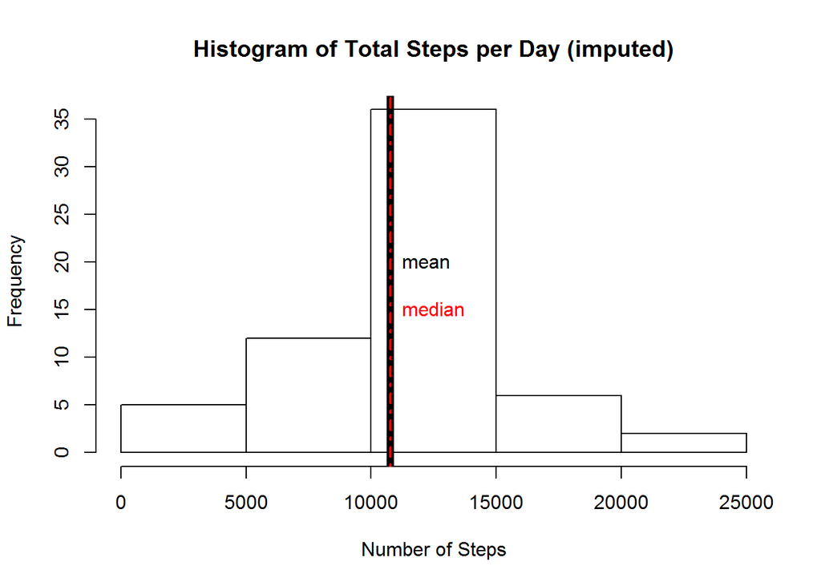

```r
# Now let's replace the missing values with the average steps calculated earlier
compData <- AD

for(i in 1:nrow(compData)) {
  if (is.na(compData$steps[i])) {
    intervalValue <- compData$interval[i]
    compData$steps[i] <- aggStepsInterval[aggStepsInterval$interval == intervalValue,]$steps
    }
}

# now use the new data to create the histogram
compStepsDay <- aggregate(steps ~ date, compData, sum)

meanCompSteps <- mean(compStepsDay$steps)
medianCompSteps <- median(compStepsDay$steps)

hist(compStepsDay$steps, main="Histogram of Total Steps per Day (imputed)", xlab="Number of Steps")
abline(v=meanCompSteps, lty=1, lwd=6, col="black")
text(meanCompSteps, 20, pos=4, labels="mean", col="black")
abline(v=medianCompSteps, lty=4, lwd=2, col="red")
text(medianCompSteps, 15, pos=4, labels = "median", col="red")
```

```r
# let's show the new mean and median values too
sprintf("mean = %.1f", meanCompSteps)
```

```
## [1] "mean = 10766.2"
```

```r
sprintf("median = %.1f", medianCompSteps)
```

```
## [1] "median = 10766.2"
```

```r
diffMeanSteps <- meanSteps - meanCompSteps

if (meanSteps > meanCompSteps){
  sprintf("The imputed data reduced the mean by %.1f", abs(diffMeanSteps))
} else if ( meanCompSteps > meanSteps){
  sprintf("The imputed data increased the mean by %.1f", abs(diffMeanSteps))
} else {
  sprintf("The mean did not change; value remained %.1f", meanSteps)
}
```

```
## [1] "The mean did not change; value remained 10766.2"
```

```r
diffMedianSteps <- medianSteps - medianCompSteps

if (medianSteps > medianCompSteps){
  sprintf("The imputed data reduced the median by %.1f", abs(diffMedianSteps))
} else if ( medianCompSteps > medianSteps){
  sprintf("The imputed data increased the median by %.1f", abs(diffMedianSteps))
} else {
  sprintf("The median did not change; value remained %.1f", medianSteps)
}
```

```
## [1] "The imputed data increased the median by 1.2"
```

#### *By imputing the missing values for steps, the mean did not change but the median increased to be exactly the same as the mean, i.e. 10,766*

## Are there differences in activity patterns between weekdays and weekends?

##### Create a new factor variable to represent weekdays and weekend days and then show a panel plot with a time series with the interval and the average number of steps for weekdays and weekend days

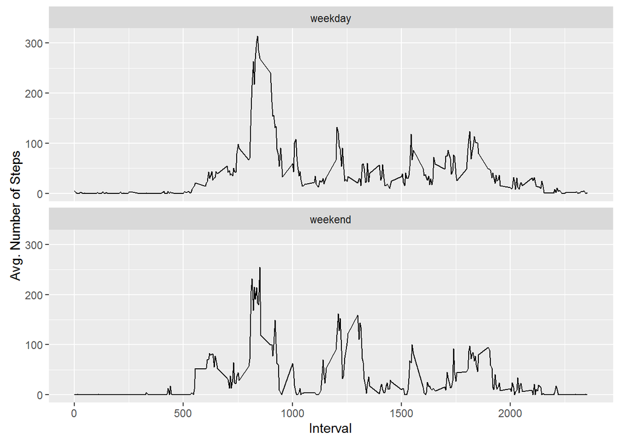

```r
# create the factor variable
compData['dayType'] <- weekdays(as.Date(compData$date))
compData$dayType[compData$dayType %in% c('Saturday','Sunday')] <- "weekend"
compData$dayType[compData$dayType != "weekend"] <- "weekday"
compData$dayType <- as.factor(compData$dayType)

#aggregate the data by interval and day type, i.e. weekday or weekend
compStepsDayType <- aggregate(steps ~ interval + dayType, compData, mean)

# create the panel plot, one panel for weekday and one panel for weekend
qplot(interval, steps, data=compStepsDayType, geom=c("line"), xlab = "Interval", ylab = "Avg. Number of Steps") + facet_wrap(~ dayType, ncol =1)
```

#### *Based on the time series data, the pattern between weekdays and weekends are relatively close although the weekdays have a higher peek number of steps.*